# An Interesting Analysis of Tooth Growth

generalinsight

July 20, 2017

### Overview

Analyzie tooth growth (data:ToothGrowth in R datasets package) to perform basic exploratory analysis, a summary of the data, model to compare tooth growth by **supp** and **dose**, and finally provide conclusions.

### Data Exploration

First, We load the data, and necessary libraries. and perform exploratory analysis.

```r
data("ToothGrowth")
library(tidyverse)
str(ToothGrowth)
```

```
## 'data.frame':    60 obs. of  3 variables:
##  $ len : num  4.2 11.5 7.3 5.8 6.4 10 11.2 11.2 5.2 7 ...
##  $ supp: Factor w/ 2 levels "OJ","VC": 2 2 2 2 2 2 2 2 2 2 ...
##  $ dose: num  0.5 0.5 0.5 0.5 0.5 0.5 0.5 0.5 0.5 0.5 ...
```

```r
summary(ToothGrowth)
```

```
##       len        supp         dose
##  Min.   : 4.20   OJ:30   Min.   :0.500
##  1st Qu.:13.07   VC:30   1st Qu.:0.500
##  Median :19.25           Median :1.000
##  Mean   :18.81           Mean   :1.167
##  3rd Qu.:25.27           3rd Qu.:2.000
##  Max.   :33.90           Max.   :2.000
```

```r
head(ToothGrowth,10)
```

```
##     len supp dose
## 1   4.2   VC  0.5
## 2  11.5   VC  0.5
## 3   7.3   VC  0.5
## 4   5.8   VC  0.5
## 5   6.4   VC  0.5
## 6  10.0   VC  0.5
## 7  11.2   VC  0.5
## 8  11.2   VC  0.5
## 9   5.2   VC  0.5
## 10  7.0   VC  0.5
```

We plan to model **len** on **supp** (2 level factor) and **dose** (only 3 levels); We change dose to being factors.

```r
ToothGrowth$dose <- as.factor(ToothGrowth$dose)
```

### Data Summary

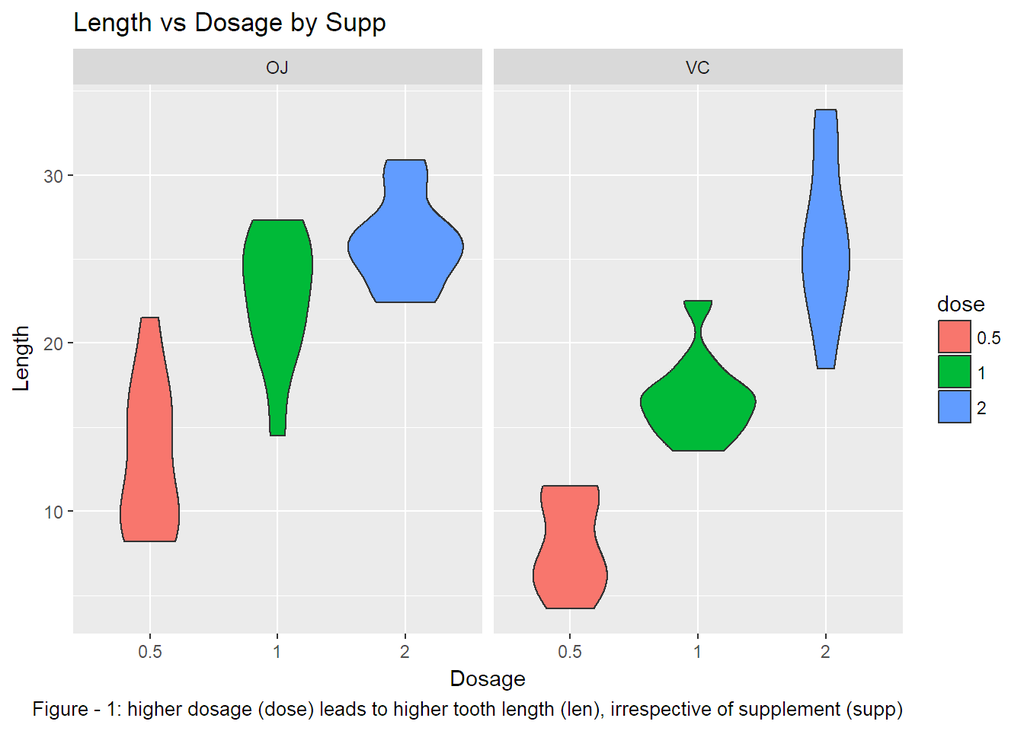

```r
ggplot(ToothGrowth, aes(dose, len)) +
        geom_violin(aes(fill = dose)) +
        facet_grid(.~ supp) +
        labs(x = "Dosage", y = "Length", title = "Length vs Dosage by Supp", caption = "Figure - 1: higher dosage (dose) leads to higher tooth length (len), irrespective of supplement (supp)")
```

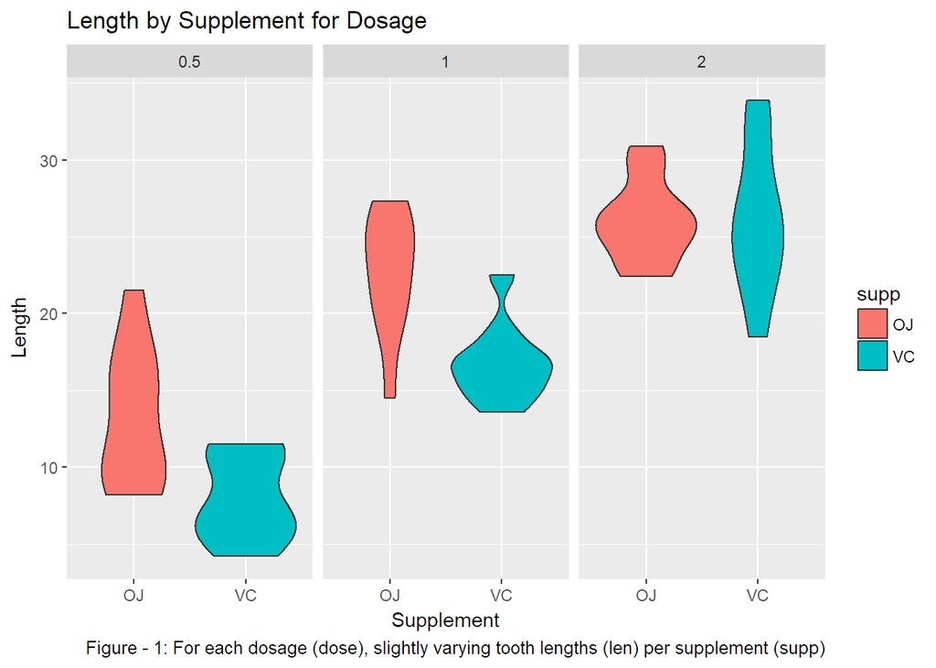

```r
ggplot(ToothGrowth, aes(supp, len)) +
        geom_violin(aes(fill = supp)) +
        facet_grid(.~ dose) +
        labs(x = "Supplement", y = "Length", title = "Length by Supplement for Dosage", caption = "Figure - 1: For each dosage (dose), slightly varying tooth lengths (len) per supplement (supp)")
```

### Model

Now we move to modeliing the data to thru confidence interval and hypothesis testing

```r
t.test(len ~ supp, ToothGrowth)
```

```
##
##  Welch Two Sample t-test
##
## data:  len by supp
## t = 1.9153, df = 55.309, p-value = 0.06063
## alternative hypothesis: true difference in means is not equal to 0
## 95 percent confidence interval:
##  -0.1710156  7.5710156
## sample estimates:
## mean in group OJ mean in group VC
##         20.66333         16.96333
```

**Below, we are doing a series of comparison on tooth growth by dosage.**

```r
t1 <- subset(ToothGrowth, ToothGrowth$dose %in% c(0.5, 1.0))
t.test(len ~ dose, t1)
```

```
##
##  Welch Two Sample t-test
##
## data:  len by dose
## t = -6.4766, df = 37.986, p-value = 1.268e-07
## alternative hypothesis: true difference in means is not equal to 0
## 95 percent confidence interval:
##  -11.983781  -6.276219
## sample estimates:
## mean in group 0.5   mean in group 1
##            10.605            19.735
```

```r
t1 <- subset(ToothGrowth, ToothGrowth$dose %in% c(0.5, 2.0))
t.test(len ~ dose, t1)
```

```
##
##  Welch Two Sample t-test
##
## data:  len by dose
## t = -11.799, df = 36.883, p-value = 4.398e-14
## alternative hypothesis: true difference in means is not equal to 0
## 95 percent confidence interval:
##  -18.15617 -12.83383
## sample estimates:
## mean in group 0.5   mean in group 2
##            10.605            26.100
```

```r
t1 <- subset(ToothGrowth, ToothGrowth$dose %in% c(1.0, 2.0))
t.test(len ~ dose, t1)
```

```
##
##  Welch Two Sample t-test
##
## data:  len by dose
## t = -4.9005, df = 37.101, p-value = 1.906e-05
## alternative hypothesis: true difference in means is not equal to 0
## 95 percent confidence interval:
##  -8.996481 -3.733519
## sample estimates:
## mean in group 1 mean in group 2
##          19.735          26.100
```

Based on the results - none of the confidence intervals include 0, as well, the p-values are substanltially small for every tests.

### Conclusion

Therefore, we can reject null hypothesis, eg we find that tooth length increases with dosage increased.